# Chapter 4 - PCA: exercises

Author

Prof. Richard Wilkinson

## Question 1

1. Consider the following data in $\mathbb{R}^2$

$$\mathbf x_1 =\begin{pmatrix}1\\-1\end{pmatrix},\; \mathbf x_2 =\begin{pmatrix}-1\\1\end{pmatrix},
\;\mathbf x_3 =\begin{pmatrix}2\\2\end{pmatrix}$$

- What is the orthogonal projection of these points onto
  $$\mathbf u_1 = \begin{pmatrix}1\\0\end{pmatrix}$$
  and onto
  $$\mathbf u_2 =\frac{1}{\sqrt{5}}\begin{pmatrix}1\\2\end{pmatrix}?$$
- Compute the sample variance matrix of the data points, and compute its spectral decomposition.
- Which unit vector $\mathbf u$ would maximize the variance of these projections?
- What vector $\mathbf u$ would minimize
  $$\sum_{i=1}^4 ||\mathbf x_i -\mathbf u\mathbf u^\top \mathbf x_i||^2_2?$$
  This is the sum of squared errors from a rank 1 approximation to the data.
- Plot the data points and convince yourself that your answers make intuitive sense.

**Solution**

- The projection of $\mathbf x$ onto $\mathbf u$ is $\mathbf u(\mathbf x^\top \mathbf u)$ giving points

$$\mathbf u_1 (\mathbf x_1^\top \mathbf u_1)=\begin{pmatrix}1\\0\end{pmatrix}, \quad
\mathbf u_1 (\mathbf x_2^\top \mathbf u_1)=\begin{pmatrix}-1\\0\end{pmatrix}, \quad
\mathbf u_1 (\mathbf x_3^\top \mathbf u_1)=\begin{pmatrix}2\\0\end{pmatrix}$$
Or, if we just want to give the coordinates of the projections with respect to basis $\mathbf u_1$ we get
$$\mathbf x_1^\top \mathbf u_1=1, \quad
\mathbf x_2^\top \mathbf u_1=-1, \quad
\mathbf x_3^\top \mathbf u_1=2$$
We can do the same calculation to project onto $\mathbf u_2$
$$\mathbf u_2 (\mathbf x_1^\top \mathbf u_2)=\frac{1}{5}\begin{pmatrix}-1\\-2\end{pmatrix}, \quad
\mathbf u_2 (\mathbf x_2^\top \mathbf u_2)=\frac{1}{5}\begin{pmatrix}1\\2\end{pmatrix}, \quad
\mathbf u_2 (\mathbf x_3^\top \mathbf u_2)=\frac{6}{5}\begin{pmatrix}1\\2\end{pmatrix}$$

- The data matrix is
  $$\mathbf X=\begin{pmatrix}1 &-1\\
  -1 & 1\\
  2 & 2
  \end{pmatrix}, \mbox{ so } \bar{\mathbf x} = (\frac{2}{3}, \frac{2}{3})^\top$$

Thus
$$\mathbf H\mathbf X= \begin{pmatrix}\frac{1}{3} &-\frac{5}{3}\\
-\frac{5}{3} & \frac{1}{3}\\
\frac{4}{3} & \frac{4}{3}
\end{pmatrix}\mbox{ and } \mathbf S= \frac{1}{3}\mathbf X^\top \mathbf H\mathbf X= \frac{1}{9}\begin{pmatrix} 14&2\\
2 & 14\end{pmatrix}$$

Check

```r
X <- matrix(c(1, -1, -1,1, 2,2), nr=3, byrow=T)
(HX <- sweep(X,2, colMeans(X)))
```

```
           [,1]       [,2]
[1,]  0.3333333 -1.6666667
[2,] -1.6666667  0.3333333
[3,]  1.3333333  1.3333333
```

```r
cov(X)*2/3# factor of n-1/n is there to adjust from R's unbiased estimator to the MLE.
```

```
          [,1]      [,2]
[1,] 1.5555556 0.2222222
[2,] 0.2222222 1.5555556
```

```r
(S=1/3 * t(X)%*%HX)
```

```
          [,1]      [,2]
[1,] 1.5555556 0.2222222
[2,] 0.2222222 1.5555556
```

The eigenvalues of $\mathbf S$ are $\frac{16}{9}$ and $\frac{4}{3}$ with corresponding eigenvectors $\frac{1}{\sqrt{2}}(1,1)^\top$ and $\frac{1}{\sqrt{2}}(-1,1)^\top$. Thus the spectral decomposition of $\mathbf S$ is

$$\mathbf S= \frac{1}{\sqrt{2}}\begin{pmatrix} 1&-1\\
1 & 1\end{pmatrix}\begin{pmatrix} \frac{16}{9}&0\\
0 & \frac{4}{3}\end{pmatrix}\frac{1}{\sqrt{2}}\begin{pmatrix} 1&-1\\
1 & 1\end{pmatrix}^\top$$

Check:

```r
Q <- 1/sqrt(2)* matrix(c(1,-1,1,1), nr=2, byrow=T)
Lambda <- diag(c(16/9, 4/3))
Q%*%Lambda %*%t(Q)-S
```

```
              [,1]          [,2]
[1,] -2.220446e-16 -1.110223e-16
[2,] -1.110223e-16 -2.220446e-16
```

Note that the difference between Q and S is not zero due to numerical errors that occur when doing floating point arithmetic on a computer.

- From the notes, we know the variance of the projections are maximized when projecting onto the first eigenvector $\frac{1}{\sqrt{2}}\begin{pmatrix} 1\\ 1 \end{pmatrix}$.
- Similarly, we know that to minimize the reconstruction error, we again must project onto the first eigenvector $\frac{1}{\sqrt{2}}\begin{pmatrix} 1\\ 1 \end{pmatrix}$.

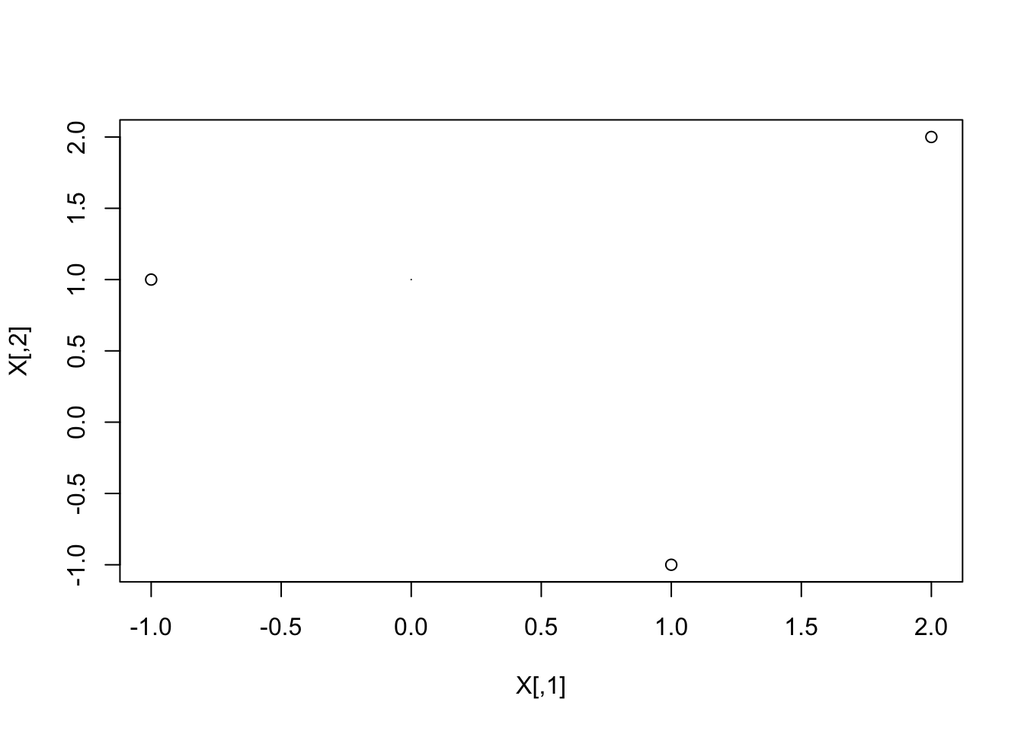

```r
plot(X)
lines(c(0,0), c(1,1))
```

## Question 2

Consider a population covariance matrix $\boldsymbol{\Sigma}$ of the form
$$\boldsymbol{\Sigma}=\gamma \mathbf I_p + \mathbf a\mathbf a^\top$$
where $\gamma>0$ is a scalar, $\mathbf I_p$ is the $p \times p$ identity matrix and $\mathbf a$ is a vector of dimension $p$.

- Show that $\mathbf a$ is an eigenvector of $\boldsymbol{\Sigma}$.
- Show that if $\mathbf b$ is any vector such that $\mathbf a^\top \mathbf b=0$, then $\mathbf b$ is also an eigenvector of $\boldsymbol{\Sigma}$. What is the eigenvalue corresponding to $\mathbf b$?
- Obtain all the eigenvalues of $\boldsymbol{\Sigma}$.
- Determine expressions for the proportion of variability ‘explained’ by:
  1. the largest (population) principal component of $\boldsymbol{\Sigma}$;
  2. the $r$ largest (population) principal components of $\boldsymbol{\Sigma}$, where $1 < r \leq p$.

**Solution**

- An eigenvector will satisfy $\boldsymbol{\Sigma}\mathbf a= \lambda \mathbf a$ for some scalar $\lambda$. We have
  $$\boldsymbol{\Sigma}\mathbf a= (\gamma \mathbf I_p + \mathbf a\mathbf a^\top) \mathbf a= \gamma \mathbf I_p \mathbf a+ \mathbf a(\mathbf a^\top \mathbf a) = \gamma \mathbf a+ (\mathbf a^\top \mathbf a) \mathbf a= \lambda \mathbf a$$
  where $\lambda = \gamma + \mathbf a^\top \mathbf a$. Thus $\mathbf a$ is an eigenvector of $\boldsymbol{\Sigma}$.
- If $\mathbf b$ is such that $\mathbf a^\top \mathbf b=0$, then
  $$\boldsymbol{\Sigma}\mathbf b= (\gamma \mathbf I_p + \mathbf a\mathbf a^\top) \mathbf b= \gamma \mathbf b+ \mathbf a(\mathbf a^\top \mathbf b) = \lambda \mathbf b,$$
  where $\lambda = \gamma$. Thus $\mathbf b$ is an eigenvector of $\boldsymbol{\Sigma}$ corresponding to eigenvalue $\gamma$. Let’s check:

```r
p=5
gamma=2
a <- matrix(c(1:p), nc=1)
sigma = gamma*diag(rep(1,p))+a%*%t(a)
eigen(sigma)$values
```

```
[1] 57  2  2  2  2
```

- From part (a) we know one eigenvalue is $\gamma + \mathbf a^\top \mathbf a$ and from part (b) we know the eigenvalue corresponding to $\mathbf b$ is $\gamma$. The subspace $\{\mathbf b: \mathbf a^\top\mathbf b=0\}$ has dimension $p-1$. Therefore the eigenvalue $\gamma$ has multiplicity $p-1$. Moreover, $\mathbf a^\top \mathbf a> 0$ if $\mathbf a\neq \boldsymbol 0$, in which case $\gamma + \mathbf a^\top \mathbf a> \gamma$, so $\lambda_1 = \gamma + \mathbf a^\top \mathbf a$ is the largest eigenvalue of $\boldsymbol{\Sigma}$, and the remaining eigenvalues are $\lambda_2 = \lambda_3 = \ldots = \lambda_p = \gamma$.

**Aside:** How do we know the subspace
$$\{\mathbf b: \mathbf a^\top\mathbf b=0\} \subset \mathbb{R}^p$$
has dimension $p-1$? We can see this from the rank-nullity theorem. Consider the linear map from $\mathbb{R}^p$ to $\mathbb{R}$ given by
$$A: \mathbf b\mapsto \mathbf a^\top\mathbf b$$
Then the rank nullity theorem gives us that
$$\dim \operatorname{Im}(A)+\dim \operatorname{Ker}(A) = p$$
Clearly $\dim \operatorname{Im}(A)=1$, and so $\dim \operatorname{Ker}(A) =p-1$. But the kernel of A is just the subspace we’re interested in:
$$\operatorname{Ker}(A)=\{\mathbf b: \mathbf a^\top\mathbf b=0\} \subset \mathbb{R}^p$$

- The proportion of variability explained by largest eigenvalue is
  $$\frac{\lambda_1}{\sum_{i=1}^p \lambda_i} = \frac{\gamma + \mathbf a^\top \mathbf a}{\gamma + \mathbf a^\top \mathbf a+ (p-1)\gamma} = \frac{\gamma + \mathbf a^\top \mathbf a}{p \gamma + \mathbf a^\top \mathbf a}.$$
- The proportion of variability explained by the $r$ largest eigenvalues is
  $$\frac{\sum_{i=1}^r \lambda_i}{\sum_{i=1}^p \lambda_i} = \frac{\gamma + \mathbf a^\top \mathbf a+ (r-1) \gamma}{p \gamma + \mathbf a^\top \mathbf a} = \frac{r \gamma + \mathbf a^\top \mathbf a}{p \gamma + \mathbf a^\top \mathbf a}.$$

## Question 3

A covariance matrix has the following eigenvalues:

```
 [1] 4.22 2.38 1.88 1.11 0.91 0.82 0.58 0.44 0.35 0.19 0.05 0.04 0.04
```

- Sketch a scree plot.
- Determine the minimum number of principal components needed to explain 90% of the total variation.
- Determine the number of principal components whose eigenvalues are above average.

**Solution**

- The percentage of variance explained by the $i$th principal component is
  $$\frac{100 \lambda_i}{\sum_{j=1}^p \lambda_j} = \frac{100 \lambda_i}{13.01}.$$
  The percentage of variance explained by each of the principal component is, therefore,

```r
lambda <- c(4.22 , 2.38 , 1.88 , 1.11 , 0.91 , 0.82 , 0.58, 0.44 , 0.35 , 0.19 , 0.05 , 0.04 , 0.04)

lambda/sum(lambda)*100
```

```
 [1] 32.4365872 18.2936203 14.4504228  8.5318985  6.9946195  6.3028440
 [7]  4.4581091  3.3820138  2.6902383  1.4604151  0.3843198  0.3074558
[13]  0.3074558
```

The scree plot is

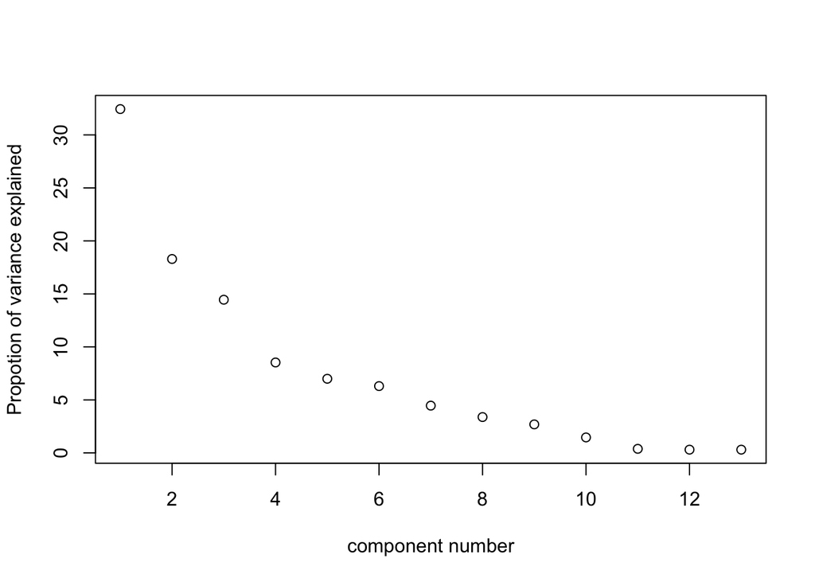

```r
plot(1:length(lambda), lambda/sum(lambda)*100, ylab="Propotion of variance explained", xlab='component number')
```

Also useful is a plot of the cummulative variance explained by the first $k$ components

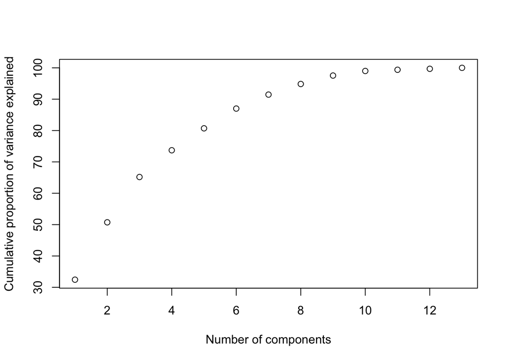

```r
plot(1:length(lambda), 100*cumsum(lambda)/sum(lambda), ylab="Cumulative proportion of variance explained",
     xlab="Number of components")
```

- The first six principal components explain 87.01% of the total variation and the first seven principal components explain 91.4% of the total variation. Therefore, we need 7 principal components to explain 90% of the total variation.
- The average of the eigenvalues is $\bar{\lambda} = \sum_j \lambda_j/p = 13.01/13 = 1.00$. There are 4 eigenvalues above this value so, using this criterion, we would retain the first four principal components.

```r
which(cumsum(lambda)/sum(lambda)>0.9)
```

```
[1]  7  8  9 10 11 12 13
```

```r
which(lambda>mean(lambda))
```

```
[1] 1 2 3 4
```

## Question 4

Measurements are taken on $p=3$ variables $x_1$, $x_2$ and $x_3$, with sample correlation matrix
$$\mathbf R= \begin{pmatrix} 1 & 0.5792 & 0.2414 \\ 0.5792 & 1 & 0.5816 \\ 0.2414 & 0.5816 & 1 \end{pmatrix}.$$
The variable $z_j$ is the standardised versions of $x_j$, $j=1,2,3$, i.e. each $z_j$ has sample mean $0$ and variance $1$. One observation has $z_1 = z_2 = z_3 = 0$ and a second observation has $z_1 = z_2 = z_3 =1$. Calculate the three principal component scores for each of these observations.

**Solution**

- The sample covariance matrix of the $\mathbf z_i$ is $\mathbf R$, which is also the sample correlation matrix of the $\mathbf x_i$. To find the principal components we need to find the eigenvalues and eigenvectors of $\mathbf R$.

```r
R = matrix(c(1, 0.5792 , 0.2414,0.5792 , 1 , 0.5816, 0.2414 , 0.5816 , 1), nr=3, byrow=TRUE)
eigen(R)
```

```
eigen() decomposition
$values
[1] 1.9503376 0.7586025 0.2910599

$vectors
           [,1]        [,2]       [,3]
[1,] -0.5344780  0.70887157  0.4602547
[2,] -0.6536495 -0.00147049 -0.7567960
[3,] -0.5357944 -0.70533604  0.4641395
```

Using R, we find that
$$\mathbf R=\mathbf V\boldsymbol \Lambda\mathbf V^{\top}$$
where $\mathbf V$ is the orthogonal matrix of eigenvectors
$$\mathbf V=[\mathbf v_1, \mathbf v_2,\mathbf v_3]=\begin{pmatrix} -0.5345& 0.7089 & 0.4603\\-0.6536 & -0.0015 & -0.7568\\-0.5358 & -0.7053 & 0.4641 \end{pmatrix},$$
and $\boldsymbol \Lambda$ is the diagonal matrix of eigenvalues given by
$$\boldsymbol \Lambda=\begin{pmatrix} 1.9503&0&0\\0&0.7586& 0\\0 &0 &0.2911 \end{pmatrix},$$

The principal component scores are given by $y_j = \mathbf v_j^\top(\mathbf z- \bar{\mathbf z})$ for $j=1,2,3$. The measurements are standardised so $\bar{\mathbf z} = \boldsymbol 0$. Therefore for the first observation, $\mathbf z= (0,0,0)^\top$, the principal component scores are all zero. For the second observation, $\mathbf z= (1,1,1)^\top$, the principal component scores are
$$\begin{eqnarray*}
y_1 &=& \mathbf v_1^\top \mathbf z= -0.5345 + -0.6536 + -0.5358 = -1.7239, \\
y_2 &=& \mathbf v_2^\top \mathbf z= 0.7089 - 0.0015 - 0.7053 = 0.0021, \\
y_3 &=& \mathbf v_3^\top \mathbf z= 0.4603 - 0.7568 + 0.4641 = 0.1676. \\
\end{eqnarray*}$$

## Question 5

Try exam question 1 part (a) from the 2017-18 exam paper.

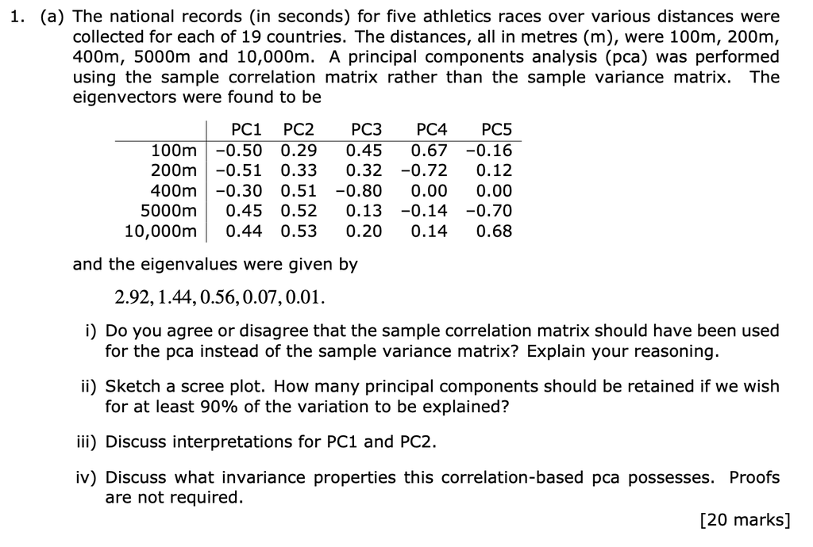

**Solution**

1. Agree. Although the distances are all measured in seconds, the variances will be very different. PCA based on the variance matrix would be dominated by the records in the 5000 and 10,000m races, so we should used PCA based on the correlation matrix.

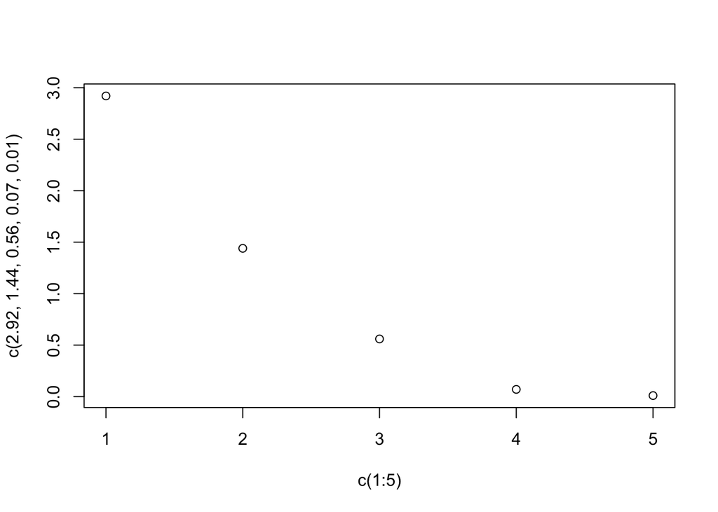

$$\frac{2.92+1.44}{2.92+1.44+0.56+0.07+0.01}<0.9<\frac{2.92+1.44+0.56}{2.92+1.44+0.56+0.07+0.01}$$
so we should retain 3 PCs to explain at least 90% of the variance.

3. The first PC score is obtained by projecting onto PC1. So it is

$$\begin{align*}y_1 = &-0.5(\mbox{100m record}- \mbox{average 100m record})\\
&- 0.51(\mbox{200m record}- \mbox{average 200m record})\\
&-0.3(\mbox{400m record}- \mbox{average 400m record})\\
&+0.45(\mbox{5k record}- \mbox{average 5k record})\\
&+0.44(\mbox{10k record}- \mbox{average 10k record})
\end{align*}$$
So a country that had faster than average sprint records, but slower than average distance records (e.g. Jamaica), would have a large positive value for $y_1$. Conversely, a country that had slower than average sprint records but faster than average distance records (e.g. Ethiopia), would have a large negative value of $y_1$.

Working through the same reasoning, PC2 seems to measure overall quality of running, with more emphasis given to long distance events. Large values of $y_2$ would indicate poor (slow) national records, large negative values of $y_2$ would indicate fast national records across all events.

4. Correlation-based PCA is invariant to the choice of scales for the original variables, i.e., it wouldn’t matter if we measured time in seconds or hours etc. It is also invariant to translations, so we could add an arbitrary constant to each variable and it wouldn’t change the results. This is because we center the variables.

## Question 6: This is an exam question from 2019.

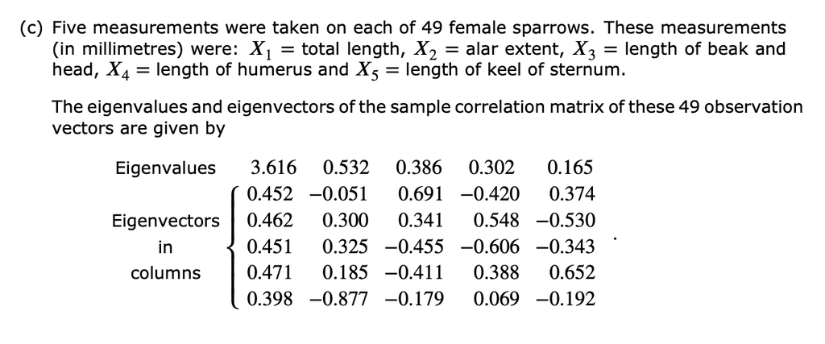

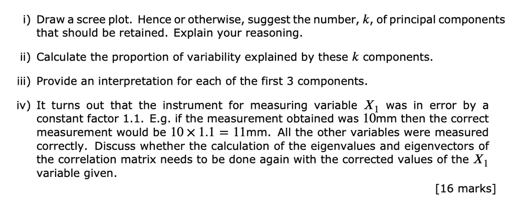

**Solution**

#### Part i)

```r
lambda <- c(3.616, 0.532, 0.386, 0.302, 0.165)
cumsum(lambda)/sum(lambda)*100
```

```
[1]  72.30554  82.94341  90.66187  96.70066 100.00000
```

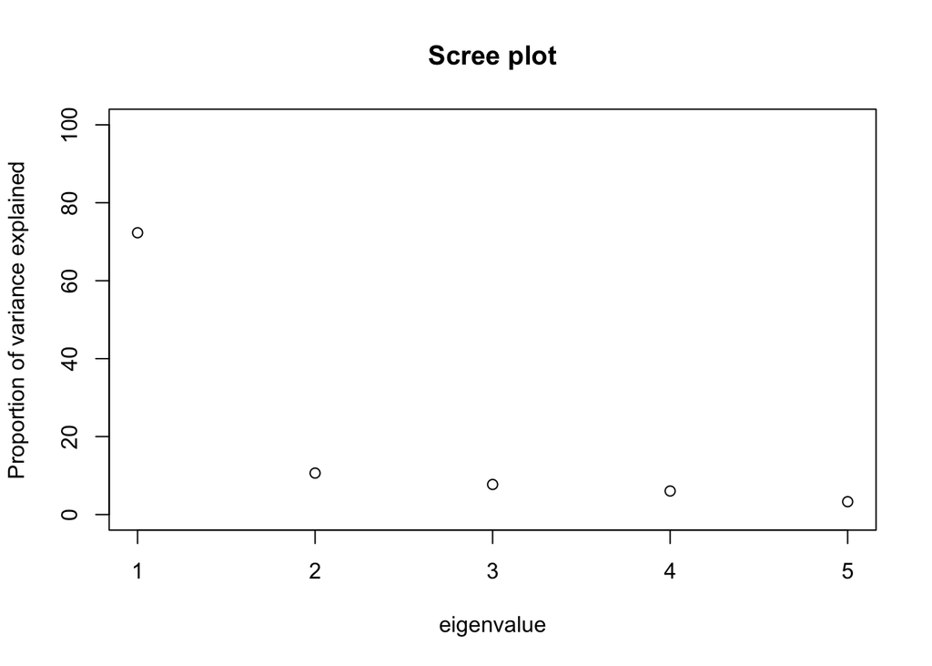

First PC explains 72% of the variance, first two PCs explain 83%, first 3 explain 91% of the variance. Retaining two or three PCs would be reasonable.

#### Part ii)

As above.

#### Part iii)

PC1 is a measure of the overall size of the sparrow.

PC2 provides a contrast between $X_2, X_3, X_4$ and $X_5$. No obvious substantive explanation.

PC3 provides a contrast between $X_1, X_2$ and $X_3, X_4, X_5$

#### Part iv)

No the calculation doesn’t need to be done again, as the sample correlation matrix was used, which is invariant to scale changes in the original variables.

If instead, the sample covariance matrix had been used then the calculation would have needed to be redone.

## Question 7: Bonus question!

Try this tricky question from the 2016 exam.

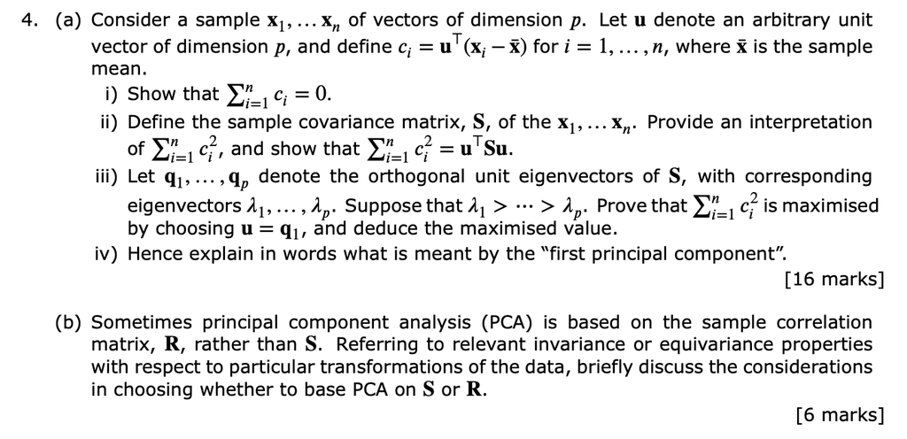

**Solution**

#### Part a)

1. $\sum c_i = \sum \mathbf u^\top(\mathbf x_i -\bar{\mathbf x}) = \mathbf u^\top(\sum \mathbf x_i - n \bar{\mathbf x})=0$
2. The sample covariance matrix is
   $$S = \frac{1}{n}\sum_{i=1}^n (\mathbf x_i -\bar{\mathbf x})(\mathbf x_i -\bar{\mathbf x})^\top$$

3. Write $S$ in terms of its spectral decomposition
   $$S=\sum_{i=1}\lambda_i \mathbf q_i\mathbf q_i^\top$$
   Then we have that
   $$\sum c_i^2 = \mathbf u^\top (\sum_{i=1}\lambda_i \mathbf q_i\mathbf q_i^\top) \mathbf u= \sum_{i=1} \lambda_i (\mathbf u^\top \mathbf q_i)^2$$
   We want to choose the unit vector $\mathbf u$ to maximize this. Because $\lambda_1 \geq \lambda_2 \geq\ldots$ we can see that
   $$\sum c_i^2 \leq \lambda_1\sum_{i=1} (\mathbf u^\top \mathbf q_i)^2=\lambda_1 \mathbf u^\top\mathbf Q\mathbf Q^\top \mathbf u=\lambda_1 \mathbf u^\top \mathbf u= \lambda_1$$
   as $\mathbf Q\mathbf Q^\top=\mathbf I$ and $\mathbf u$ is a unit vector. This is an upper bound on $\sum c_i^2=\mathbf u^\top S\mathbf u$ but it is achieved by taking $\mathbf u= \mathbf q_1$ as
   $$\mathbf q_1^\top S \mathbf q_1 =\mathbf q_1^\top (\sum \lambda_i \mathbf q_i \mathbf q_i^\top) \mathbf q_1 = \lambda_1.$$
4. The first principal component is the direction $\mathbf u$ that maximizes the variance of the projected data $c_1, \ldots, c_n$.

#### Part b)

PCA based on R is invariant to scale transformations of the data (i.e. $\mathbf x\mapsto A\mathbf x$ where $A$ is a diagonal scaling matrix). This is often preferable as then the analysis does not depend on the choice of units used to measure the components of $\mathbf x$. In particular, it avoids the problem of a single component with a large variance dominating the analysis.

PCA based on S is invariant to orthogonal rotations of the data (i.e. $\mathbf x\mapsto B\mathbf x$ where $B$ is orthogonal). Whether to base PCA on S or R depends on what kind of invariance is preferable.